# Bibliography exploration

# bibliometrix

R based software for managing bibliography in your research, offering science mapping and analysis.

Read more in their website: https://www.bibliometrix.org/home/index.php

# Installation

You can download the package directly from cran or from the bibliometrix website: https://www.bibliometrix.org/home/index.php/download

```r
#install.packages("bibliometrix ")
library(bibliometrix)
```

# Loading data

The export file can be read and converted using by R using the function convert2df:

convert2df(file, dbsource, format)

The argument file is a character vector containing the name of export files downloaded from SCOPUS, Clarivate Analytics WOS, Digital Science Dimensions, PubMed or Cochrane CDSR website. file can also contains the name of a json/xlm object download using Digital Science Dimenions or PubMed APIs (through the packages dimensionsR and pubmedR.

es. file <- c(“file1.txt”,“file2.txt”, …)

```
##
## Converting your isi collection into a bibliographic dataframe
##
## Done!
##
##
## Generating affiliation field tag AU_UN from C1:  Done!
```

convert2df creates a bibliographic data frame with cases corresponding to manuscripts and variables to Field Tag in the original export file.

convert2df accepts two additional arguments: dbsource and format.

The argument dbsource indicates from which database the collection has been downloaded.

It can be:

- “isi” or “wos” (for Clarivate Analytics Web of Science database),
- “scopus” (for SCOPUS database),
- “dimensions” (for DS Dimensions database)
- “pubmed” (for PubMed/Medline database),
- “cochrane” (for Cochrane Library database of systematic reviews).

The argument format indicates the file format of the imported collection. It can be “plaintext” or “bibtex” for WOS collection and mandatorily “bibtext” for SCOPUS collection. The argument is ignored if the collection comes from Pubmed or Cochrane.

Each manuscript contains several elements, such as authors’ names, title, keywords and other information. All these elements constitute the bibliographic attributes of a document, also called metadata.

Data frame columns are named using the standard Clarivate Analytics WoS Field Tag codify.

## Bibliometric Analysis

# Functions summary and plot

To summarize main results of the bibliometric analysis, use the generic function summary. It displays main information about the bibliographic data frame and several tables, such as annual scientific production, top manuscripts per number of citations, most productive authors, most productive countries, total citation per country, most relevant sources (journals) and most relevant keywords.

Main information table describes the collection size in terms of number of documents, number of authors, number of sources, number of keywords, timespan, and average number of citations.

Furthermore, many different co-authorship indices are shown. In particular, the Authors per Article index is calculated as the ratio between the total number of authors and the total number of articles. The Co-Authors per Articles index is calculated as the average number of co-authors per article. In this case, the index takes into account the author appearances while for the “authors per article” an author, even if he has published more than one article, is counted only once. For that reasons, Authors per Article index ≤ Co-authors per Article index.

The Collaboration Index (CI) is calculated as Total Authors of Multi-Authored Articles/Total Multi-Authored Articles (Elango and Rajendran, 2012; Koseoglu, 2016). In other word, the Collaboration Index is a Co-authors per Article index calculated only using the multi-authored article set.

Elango, B., & Rajendran, P. (2012). Authorship trends and collaboration pattern in the marine sciences literature: a scientometric study. International Journal of Information Dissemination and Technology, 2(3), 166.

Koseoglu, M. A. (2016). Mapping the institutional collaboration network of strategic management research: 1980–2014. Scientometrics, 109(1), 203-226.

summary accepts two additional arguments. k is a formatting value that indicates the number of rows of each table. pause is a logical value (TRUE or FALSE) used to allow (or not) pause in screen scrolling. Choosing k=10 you decide to see the first 10 Authors, the first 10 sources, etc.

```r
options(width=100)
S <- summary(object = results, k = 10, pause = FALSE)
```

```
##
##
## MAIN INFORMATION ABOUT DATA
##
##  Timespan                              1985 : 2015
##  Sources (Journals, Books, etc)        141
##  Documents                             291
##  Annual Growth Rate %                  7.18
##  Document Average Age                  19.7
##  Average citations per doc             11.73
##  Average citations per year per doc    0.5463
##  References                            6769
##
## DOCUMENT TYPES
##  art exhibit review              1
##  article                         160
##  article; proceedings paper      7
##  biographical-item               1
##  book review                     32
##  correction, addition            1
##  editorial material              41
##  letter                          16
##  meeting abstract                4
##  note                            3
##  review                          25
##
## DOCUMENT CONTENTS
##  Keywords Plus (ID)                    475
##  Author's Keywords (DE)                365
##
## AUTHORS
##  Authors                               565
##  Author Appearances                    673
##  Authors of single-authored docs       121
##
## AUTHORS COLLABORATION
##  Single-authored docs                  144
##  Documents per Author                  0.515
##  Co-Authors per Doc                    2.31
##  International co-authorships %        12.37
```

[output cut: 118 more lines]

```
##
##
## Most Relevant Keywords
##
##    Author Keywords (DE)      Articles Keywords-Plus (ID)     Articles
## 1      BIBLIOMETRICS               63    SCIENCE                   38
## 2      CITATION ANALYSIS           11    INDICATORS                24
## 3      SCIENTOMETRICS               7    IMPACT                    23
## 4      IMPACT FACTOR                5    CITATION                  20
## 5      INFORMATION RETRIEVAL        5    CITATION ANALYSIS         15
## 6      PEER REVIEW                  5    JOURNALS                  14
## 7      CITATION                     4    H-INDEX                   13
## 8      CITATIONS                    4    PUBLICATION               12
## 9      H-INDEX                      4    INFORMATION-SCIENCE       10
## 10     IMPACT FACTORS               4    IMPACT FACTORS             8
```

Some basic plots can be drawn using the generic function :

[figure not shown]

[figure not shown]

[figure not shown]

[figure not shown]

[figure not shown]

```r
plot(x = results, k = 10, pause = FALSE)
```

# Analysis of Cited References

The function citations generates the frequency table of the most cited references or the most cited first authors (of references).

For each manuscript, cited references are in a single string stored in the column “CR” of the data frame.

For a correct extraction, you need to identify the separator field among different references, used by ISI or SCOPUS database. Usually, the default separator is “;” or “.” (a dot with double space).

## The most frequent cited manuscripts:

```r
CR <- citations(M, field = "article", sep = ";")
cbind(CR$Cited[1:10])
```

```
##                                                                                 [,1]
## HIRSCH JE, 2005, P NATL ACAD SCI USA, V102, P16569, DOI 10.1073/PNAS.0507655102   29
## PRITCHAR.A, 1969, J DOC, V25, P348                                                22
## SMALL H, 1973, J AM SOC INFORM SCI, V24, P265, DOI 10.1002/ASI.4630240406         20
## DE SOLLA PRICE DJ, 1963, LITTLE SCI BIG SCI                                       19
## BRADFORD S. C, 1934, ENGINEERING-LONDON, V137, P85                                14
## GARFIELD E, 2006, JAMA-J AM MED ASSOC, V295, P90, DOI 10.1001/JAMA.295.1.90       12
## MOED H. F., 2005, CITATION ANAL RES EV                                            12
## COLE FRANCIS J., 1917, SCI PROGR, V11, P578                                       11
## GROSS P L, 1927, SCIENCE, V66, P385, DOI 10.1126/SCIENCE.66.1713.385              11
## LOTKA A. Y., 1926, J WASHINGTON ACAD SC, V16, P317                                11
```

## The most frequent cited first authors:

```r
CR <- citations(M, field = "author", sep = ";")
cbind(CR$Cited[1:10])
```

```
##               [,1]
## GARFIELD E     167
## KOSTOFF RN     129
## BORNMANN L      92
## SMALL H         75
## WHITE HD        74
## CRONIN B        67
## NARIN F         51
## GLANZEL W       50
## LEYDESDORFF L   47
## EGGHE L         45
```

```r
CR <- localCitations(M, sep = ";")
CR$Authors[1:10,]
```

```
##          Author LocalCitations
## 26     BARKER K              9
## 209    HOLDEN G              9
## 424 ROSENBERG G              9
## 1      ABRAMO G              8
## 93  D'ANGELO CA              8
## 56   BROADUS RN              7
## 221  HUMENIK JA              6
## 259  KOSTOFF RN              6
## 389    PFEIL KM              6
## 496  TSHITEYA R              6
```

# Authors’ Dominance ranking

The function dominance calculates the authors’ dominance ranking as proposed by Kumar & Kumar, 2008.

Kumar, S., & Kumar, S. (2008). Collaboration in research productivity in oil seed research institutes of India. In Proceedings of Fourth International Conference on Webometrics, Informetrics and Scientometrics.

Function arguments are: results (object of class bibliometrix) obtained by biblioAnalysis; and k (the number of authors to consider in the analysis).

```r
DF <- dominance(results, k = 10)
DF
```

```
##         Author Dominance Factor Tot Articles Single-Authored Multi-Authored First-Authored Rank by Articles Rank by DF
## 1   KOSTOFF RN        1.0000000            8               0              8              8                1          1
## 2     WHITE HD        1.0000000            4               3              1              1                5          1
## 3   BORGMAN CL        1.0000000            3               2              1              1                9          1
## 4     HOLDEN G        1.0000000            3               0              3              3                9          1
## 5   BORNMANN L        0.8333333            8               2              6              5                1          5
## 6     ABRAMO G        0.7500000            4               0              4              3                5          6
## 7      GARG KC        0.7500000            4               0              4              3                5          6
## 8    GLANZEL W        0.6000000            5               0              5              3                3          8
## 9       MARX W        0.2500000            5               1              4              1                3          9
## 10 D'ANGELO CA        0.2500000            4               0              4              1                5          9
```

# Authors’ h-index

The h-index is an author-level metric that attempts to measure both the productivity and citation impact of the publications of a scientist or scholar.

The index is based on the set of the scientist’s most cited papers and the number of citations that they have received in other publications.

The function Hindex calculates the authors’ H-index or the sources’ H-index and its variants (g-index and m-index) in a bibliographic collection.

Function arguments are: M a bibliographic data frame; field is character element that defines the unit of analysis in terms of authors (field = “auhtor”) or sources (field = “source”); elements a character vector containing the authors’ names (or the sources’ names) for which you want to calculate the H-index. The argument has the form c(“SURNAME1 N”,“SURNAME2 N”,…).

In other words, for each author: surname and initials are separated by one blank space. i.e for the authors ARIA MASSIMO and CUCCURULLO CORRADO, elements argument is elements = c(“ARIA M”, “CUCCURULLO C”).

To calculate the h-index of Lutz Bornmann in this collection:

```r
indices <- Hindex(M, field = "author", elements="BORNMANN L", sep = ";", years = 10)

# Bornmann's impact indices:
indices$H
```

```
##      Element h_index g_index    m_index TC NP PY_start
## 1 BORNMANN L       1       2 0.09090909  5  2     2015
```

# Top-Authors’ Productivity over the Time

The function AuthorProdOverTime calculates and plots the authors’ production (in terms of number of publications, and total citations per year) over the time.

Function arguments are: M a bibliographic data frame; k is the number of k Top Authors; graph is a logical. If graph=TRUE, the function plots the author production over time graph.

[figure not shown]

```r
topAU <- authorProdOverTime(M, k = 10, graph = TRUE)
```

# Country Scientific Collaboration

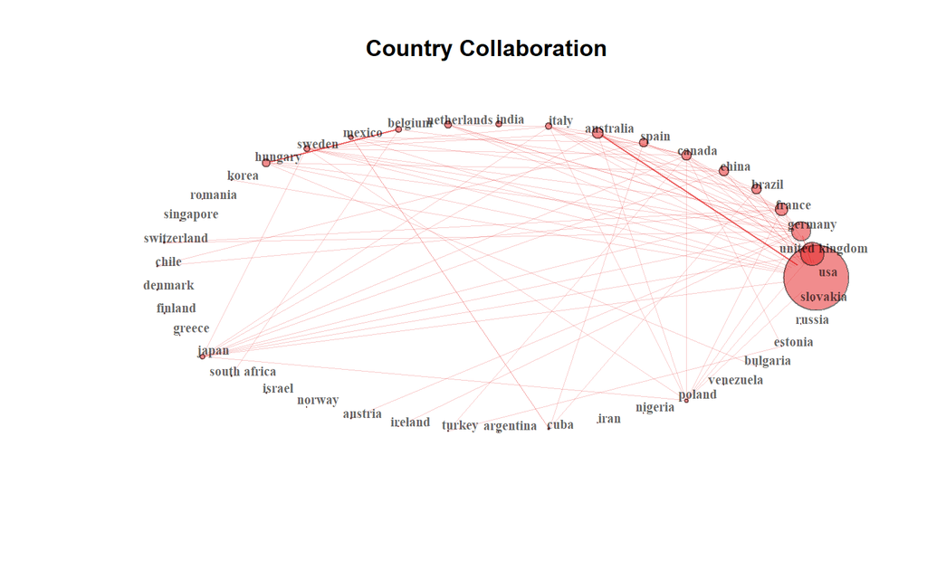

```r
# Create a country collaboration network

M <- metaTagExtraction(M, Field = "AU_CO", sep = ";")
NetMatrix <- biblioNetwork(M, analysis = "collaboration", network = "countries", sep = ";")

# Plot the network
net=networkPlot(NetMatrix, n = dim(NetMatrix)[1], Title = "Country Collaboration", type = "circle", size=TRUE, remove.multiple=FALSE,labelsize=0.7,cluster="none")
```

# Keyword co-occurrences

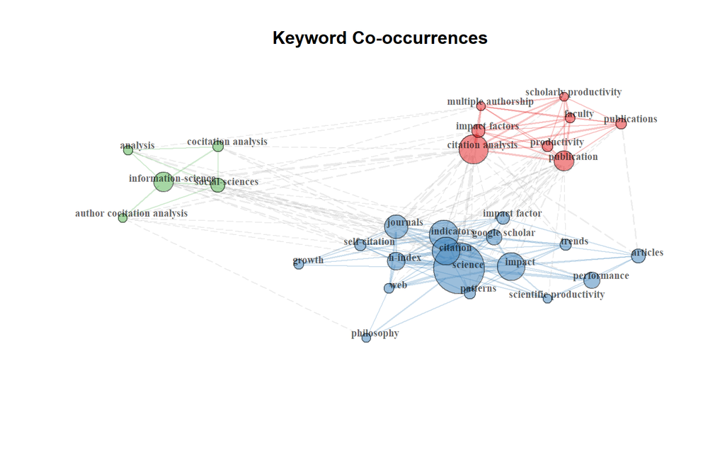

```r
# Create keyword co-occurrences network

NetMatrix <- biblioNetwork(M, analysis = "co-occurrences", network = "keywords", sep = ";")

# Plot the network
net=networkPlot(NetMatrix, normalize="association", weighted=T, n = 30, Title = "Keyword Co-occurrences", type = "fruchterman", size=T,edgesize = 5,labelsize=0.7)
```

# Co-Word Analysis: The conceptual structure of a field

The aim of the co-word analysis is to map the conceptual structure of a framework using the word co-occurrences in a bibliographic collection.

The analysis can be performed through dimensionality reduction techniques such as Multidimensional Scaling (MDS), Correspondence Analysis (CA) or Multiple Correspondence Analysis (MCA).

Here, we show an example using the function conceptualStructure that performs a CA or MCA to draw a conceptual structure of the field and K-means clustering to identify clusters of documents which express common concepts. Results are plotted on a two-dimensional map.

conceptualStructure includes natural language processing (NLP) routines (see the function termExtraction) to extract terms from titles and abstracts. In addition, it implements the Porter’s stemming algorithm to reduce inflected (or sometimes derived) words to their word stem, base or root form.

```r
# Conceptual Structure using keywords (method="CA")

CS <- conceptualStructure(M,field="ID", method="CA", minDegree=4, clust=5, stemming=FALSE, labelsize=10, documents=10)
```

[figure not shown]

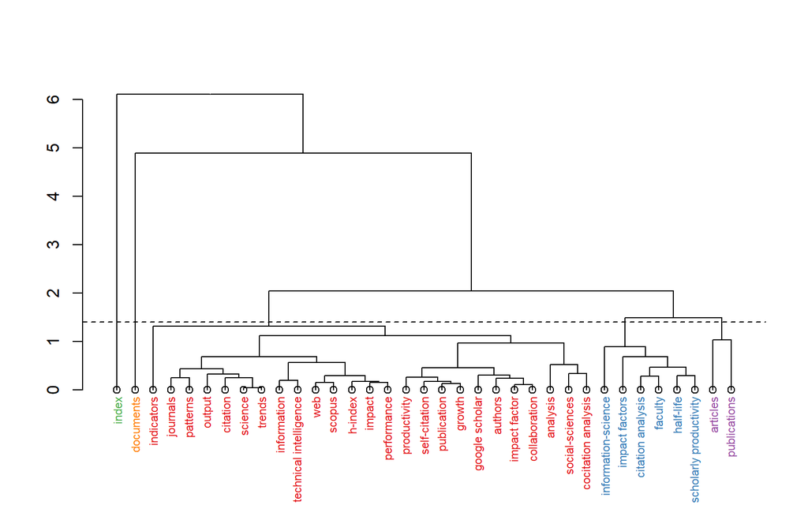

[figure not shown]

[figure not shown]

# Historical Direct Citation Network

The historiographic map is a graph proposed by E. Garfield (2004) to represent a chronological network map of most relevant direct citations resulting from a bibliographic collection.

Garfield, E. (2004). Historiographic mapping of knowledge domains literature. Journal of Information Science, 30(2), 119-145.

The function generates a chronological direct citation network matrix which can be plotted using histPlot:

```r
# Create a historical citation network
options(width=130)
histResults <- histNetwork(M, min.citations = 1, sep = ";")
```

```
##
## WOS DB:
## Searching local citations (LCS) by reference items (SR) and DOIs...
##
## Analyzing 8702 reference items...
##
## Found 49 documents with no empty Local Citations (LCS)
```

[figure not shown]

```
##
##  Legend
##
##                                                                  Label
## 1                  DEGLAS F, 1986, LIBRI DOI 10.1515/LIBR.1986.36.1.40
## 2              BROADUS RN, 1987, SCIENTOMETRICS DOI 10.1007/BF02016680
## 3           BROADUS RN, 1987, J EDUC LIBR INF SCI DOI 10.2307/40323625
## 4               PERITZ BC, 1990, SCIENTOMETRICS DOI 10.1007/BF02020148
## 5               SENGUPTA IN, 1992, LIBRI DOI 10.1515/LIBR.1992.42.2.75
## 6                   CRONIN B, 2000, J DOC DOI 10.1108/EUM0000000007123
## 7            HOOD WW, 2001, SCIENTOMETRICS DOI 10.1023/A:1017919924342
## 8  KOSTOFF RN, 2002, J POWER SOURCES DOI 10.1016/S0378-7753(02)00233-1
## 9            KOSTOFF RN, 2005, ENERGY DOI 10.1016/J.ENERGY.2004.04.058
## 10    HOLDEN G, 2005, SOC WORK HEALTH CARE DOI 10.1300/J010V41N03\\_01
## 11    HOLDEN G, 2005, SOC WORK HEALTH CARE DOI 10.1300/J010V41N03\\_03
```

[output cut: 44 more lines]

```r
# Plot a historical co-citation network
net <- histPlot(histResults, n=15, size = 10, labelsize=5)
```

# References

Adopted from : https://www.bibliometrix.org/vignettes/